# Fitting LSMs in R

Dr Tracy Sweet

May 2, 2019

We will be using the CIDnetworks R package to fit single network models. There is another R package that fit latent space models called statnet/latentnet, but we will be using CIDnetworks for several reasons. First, our goodness of fit code works with CIDnetworks objects. Second, CIDnetworks is a bit more flexible than statnet in terms of allowing missing data, a wide variety of tie values, and accommodates random sender/receiver effects.

## Loading our network data

```r
load("School1Advice.Rdata")
ls()
```

```
## [1] "edgevars"          "network.sch1"      "network.ties.sch1"
## [4] "teachers"
```

```r
## recall network.sch1 is a matrix and network.ties.sch1 is a dataframe
## We could use network.ties.sch1 but we would only want to use the first 3 columns
```

## Fitting Models in CIDnetworks

```r
library(CIDnetworks)
```

```r
## The first argument is the network; either a sociomatrix or dataframe of tie outcomes is fine
lsm0 = CID.Gibbs(network.sch1, components = c(LSM(2)), draws=300, thin=10)
```

```
## CID: Auto-detected an asymmetric sociomatrix; assuming this is a directed network.
```

```
## Fitting: ordinal outcome with 2 states.
```

```
## CIDnetwork: Reciprocal potential edges detected; assuming this is a directed network.
```

```
## Reinitializing LSM Positions
```

```
## Reciprocity: FALSE
```

```
## CID Auto-Burning In
```

[output not shown]

```
## CID Auto-Burned In. Estimated Seconds Remaining: 38
```

```
## CID 100
```

```
## CID 200
```

```
## CID 300
```

```r
## Exploring lsm0
class(lsm0)
```

```
## [1] "CID.Gibbs"
```

```r
names(lsm0)
```

```
## [1] "results"    "CID.object" "CID.mean"   "DIC"
```

```r
## lsm0$result is a list of 300 draws from the MCMC chain
## after thinning and burnin

summary(lsm0)
```

```
## Intercept:
```

```
## estimated.mean   estimated.sd           2.5%          97.5%
##         -0.264          0.229         -0.842          0.096
```

```
## Log likelihood:
```

```
## estimated.mean   estimated.sd           2.5%          97.5%
##       -186.488          7.732       -207.438       -173.074
```

```
## Mean Latent Space Positions:
```

```
##            pos1        pos2
## 1   0.068879385 -0.42295534
## 2  -0.226325716 -0.63379737
## 3  -0.127030287  0.38971746
## 4  -0.008482629  0.21736714
## 5   0.193050318  0.97038920
## 6   0.197225132  0.00317672
## 7   0.726013582 -0.87660978
## 8  -0.066794321 -1.08632910
## 9  -0.119732802 -0.43721598
## 10 -0.018212873 -0.26340681
## 11  0.646705790  0.38776381
## 12  0.644761528 -1.30301501
## 13  0.763245117  0.62879626
## 14  0.952186044  0.41796904
```

[output cut: 16 more lines]

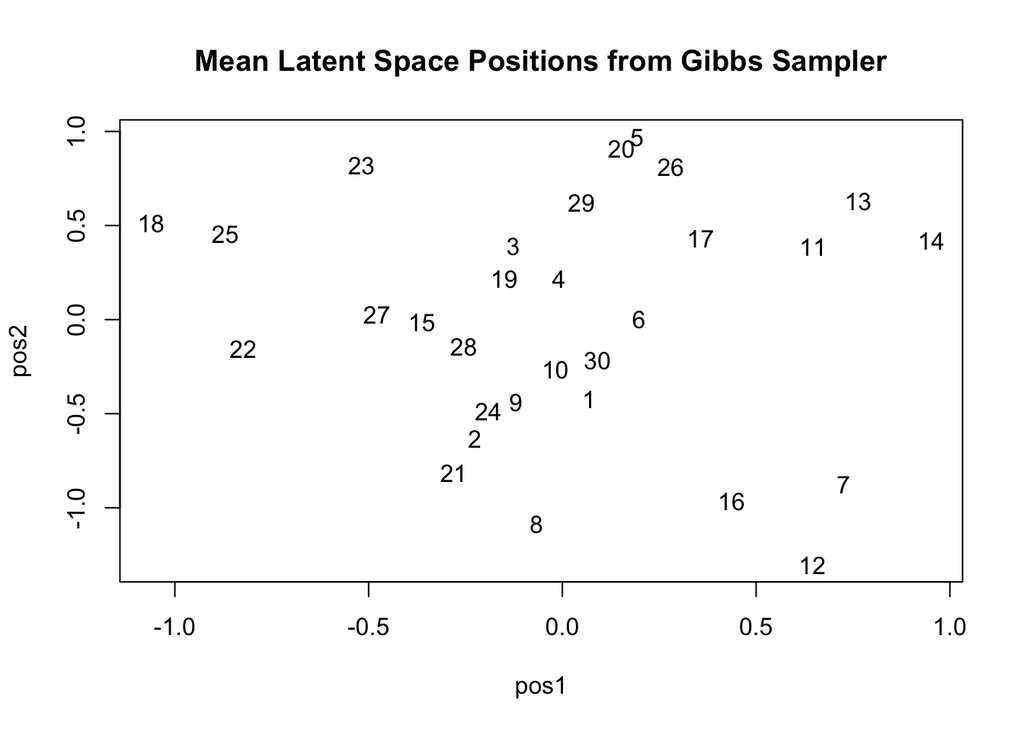

```r
LSM.plot(lsm0)
```

### Fitting LSMs with other dimensions

```r
lsm0b=CID.Gibbs(network.sch1, components = c(LSM(3)), draws=300, thin=10)
lsm0c=CID.Gibbs(network.sch1, components = c(LSM(4)), draws=300, thin=10)
```

### Fitting Covariates in LSM

```r
## Note for time, we do not thin these models.
## When fitting these models in practice, you should thin
## by at least 10 if not 20.
lsm1a=CID.Gibbs(network.sch1, components = c(LSM(2), SenderCOV(teachers), ReceiverCOV(teachers)), draws=300)
```

```
## CID: Auto-detected an asymmetric sociomatrix; assuming this is a directed network.
```

```
## Fitting: ordinal outcome with 2 states.
```

```
## CIDnetwork: Reciprocal potential edges detected; assuming this is a directed network.
```

```
## COV:  Assuming rownames correspond to node names
## COV:  Assuming rownames correspond to node names
```

```
## Reinitializing LSM Positions
```

```
## Centering covariates to speed sampler.  To disable centering pass center = FALSE
## Centering covariates to speed sampler.  To disable centering pass center = FALSE
```

```
## Reciprocity: FALSE
```

```
## CID Auto-Burning In
```

[output not shown]

```
## CID Auto-Burned In. Estimated Seconds Remaining: 46
```

```
## CID 100
```

```
## CID 200
```

```
## CID 300
```

```r
summary(lsm1a)
```

```
## Intercept:
```

```
## estimated.mean   estimated.sd           2.5%          97.5%
##         -0.106          0.113         -0.318          0.096
```

```
## Log likelihood:
```

```
## estimated.mean   estimated.sd           2.5%          97.5%
##       -171.411          5.398       -181.716       -159.854
```

```
## Mean Latent Space Positions:
```

```
##            pos1        pos2
## 1  -0.121878644  0.76632936
## 2  -0.297013884  0.63989014
## 3  -0.031237735 -1.01179371
## 4  -0.080138604 -0.28911461
## 5   1.347032836  0.49707514
## 6   0.024986858  0.16734408
## 7  -0.478429140  1.35914680
## 8  -0.475238348  1.11141812
## 9  -0.169593532  0.54941163
## 10  0.078362687  0.50590497
## 11  0.113102468 -0.79004774
## 12 -0.957448263  1.33434156
## 13  0.111843239 -0.96049994
## 14  0.001851192 -1.07395402
```

[output cut: 16 more lines]

```
## Sender Coefficients:
```

```
##          estimated.mean estimated.sd   q2.5 q97.5
## YrsExp           -0.006        0.008 -0.020 0.010
## TchTrust          0.181        0.166 -0.144 0.478
```

```
## Receiver Coefficients:
```

```
##          estimated.mean estimated.sd   q2.5 q97.5
## YrsExp            0.012        0.007  0.000 0.026
## TchTrust          0.230        0.165 -0.088 0.547
```

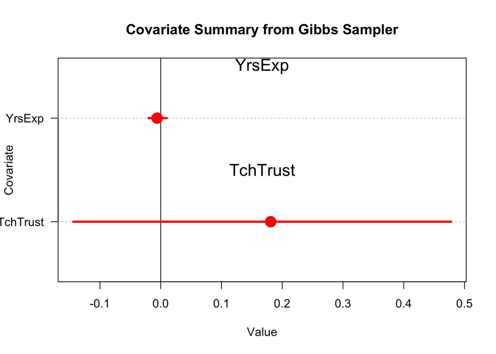

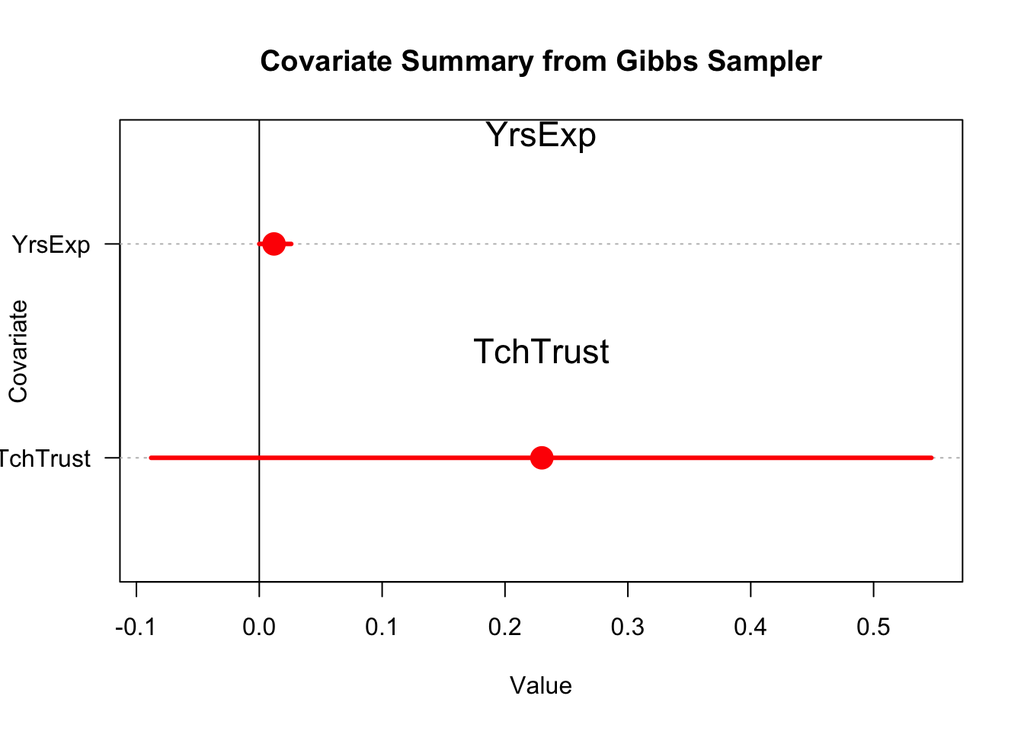

```r
COV.plot(lsm1a)
```

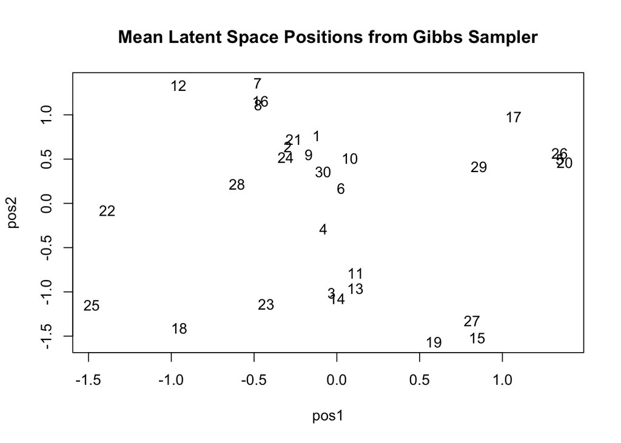

```r
LSM.plot(lsm1a)
```

Here are some more to try

```r
lsm1b=CID.Gibbs(network.sch1, components = c(LSM(2), SenderCOV(teachers), ReceiverCOV(teachers), EdgeCOV(edgevars)), draws=300)
summary(lsm1b)
COV.plot(lsm1b)
LSM.plot(lsm1b)


lsm1c=CID.Gibbs(network.sch1, components = c(LSM(2),  EdgeCOV(edgevars)), draws=300)
summary(lsm1c)
COV.plot(lsm1c)
LSM.plot(lsm1c)

lsm1d=CID.Gibbs(network.sch1, components = c(LSM(2),  EdgeCOV(edgevars[,3])), draws=300)
summary(lsm1d)
COV.plot(lsm1d)
LSM.plot(lsm1d)
```